# TRABAJO GRUPAL

**Integrantes:**

- Ronald Casafranca Zamalloa (20182202)
- Bárbara del Castillo (20173266)

**Tipo de evaluación:**

- TRABAJO FINAL

**Curso:**

- Estadística para el Análisis Político 2 (0690)

**Profesora:**

- Marylía Cruz

## Introducción

Perú es un país que presenta varios capítulos controversiales en torno a su relación con las Fuerzas Armadas y la Policía Nacional, desde participaciones durante el Conflicto Armado Interno, en las dos últimas décadas del anterior siglo, hasta desalojos arbitrarios actuales a trabajadores informales ubicados en la calle, los cuales configuran una percepción de estas Fuerzas del orden ante la opinión pública peruana. Recuérdese que las labores de la Policía Nacional y las FFAA resultan garantizar, mantener y restablecer el orden interno; así como defender al Perú de sus amenazas y proteger sus intereses respectivamente (Arhuata & Edward, 2016).

Frente a su cuestionable actuar en los conflictos socioambientales de los últimos años como el caso de Espinar, Tía María y Conga, la investigación considera que se ha generado un importante impacto en la confianza en estas instituciones junto a la permanente inseguridad y corrupción que resulta un vínculo constante en el tiempo para estas dos entidades. Estos tres problemas públicos en los que las Fuerzas del orden se ven involucradas, sugieren repensar y analizar la relación de estas con la ciudadanía para replantear y garantizar una mejor percepción pública. Por esta razón, la indagación a este problema ha conducido a establecer tres factores (variables independientes) asociados al problema observado (confianza en las Fuerzas del orden): la represión del Estado, la corrupción y la inseguridad.

Por ello, el estudio encuentra necesario observar a qué responden las variaciones en esta confianza y bajo qué mecanismos se generan. El autor Cohaila señala que la formulación de la opinión pública en temas como la corrupción se genera en base a experiencias propias y a la observación tanto directa como a través de los medios de estas problemáticas. Su despreocupación puede generar una evaluación ciudadana que guarde consecuencias gravísimas para estas instituciones, tales como una posible negación de la legitimidad pública o el establecimiento de vínculos de estas entidades frente a la captura inconstitucional del Estado. Es por ello que existe una importancia frente al estudio y supervisión periódica de este tipo de indicadores.

Según la encuesta realizada por Ipsos sobre el nivel de confianza de los peruanos en las instituciones públicas del país en septiembre del 2017, las FF.AA. cuentan con un nivel de confianza del 65%, siendo así una de las instituciones más confiables, mientras que la Policía Nacional continúa siendo vista con desconfianza por la ciudadanía (55% desconfianza).

Cabe mencionar que si bien el nivel de confianza en las FFAA se encuentra sobre los 50 puntos, Perú es uno de los países con menor índice de confianza en esta institución. Ferrer considera que esto puede ser por causa de los abusos cometidos en la lucha contra la subversión armada, sobre todo, en el gobierno de Fujimori debido a la sensación de corrupción al interior de las instituciones públicas que se vivió en aquella época, principalmente en el Ejército (2015).

Como se puede observar es altamente necesario que el vínculo de las Fuerzas del orden con la sociedad se fortalezca para así poder generar credibilidad, ya que un alto porcentaje de desconfianza puede provocar que las bases del Estado democrático se vean amenazadas y que la gobernabilidad del país se vea afectada tal como sucedió en los noventas. Lo que nos dice Carrasco sobre esto es que se deben “establecer procesos de comunicación para conocer las necesidades y expectativas de la comunidad […] de tal manera que sea posible incrementar los niveles de credibilidad, confianza y posicionamiento por parte de la ciudadanía” (2016).

Es por ello que el objetivo general de la presente investigación es identificar los factores que más influyeron en el nivel de confianza de los peruanos hacia las Fuerzas del orden (FFAA y PNP) en el 2018, mientras que los objetivos específicos consisten, por un lado, en crear un modelo a partir del cual se pueda comprender la confianza en las Fuerzas del orden para la ciudadanía peruana y, por otro lado, en establecer un perfil de una persona que confíe en estas instituciones.

De esta manera, nuestra investigación busca responder a ¿qué factores influyeron dentro del nivel de confianza en las Fuerzas del orden para la población peruana durante el 2018? Ante ello planteamos como hipótesis central que la represión del Estado, la corrupción, la inseguridad y el narcotráfico fueron los factores que más influyeron, durante el 2018, en el nivel de confianza de los peruanos hacia las Fuerzas del orden (FFAA y PNP).

## Metodología

Para este trabajo se ha realizado una investigación experimental, ya que algunas variables presentes en la data del Latinobarómetro del 2018 ha sido manipulada para efectuar los respectivos analisis que se mostrarán durante este documento. Además de ello, informar que el recojo de datos estuvo a cargo de IPSOS Perú reconociendo factores proporcionales del tamaño del estrato social y localidad en las que hubo el muestreo. Esto generó un total de 1200 casos en observación entre la encuesta realizada por el Latinobarómetro, los cuales guardan un +/-2.8 de error muestral y una representatividad del 100%.

Por esta razón, al observar que este compendio del Latinobarómetro guarda data de varios países hispanohablantes, se ha decidido inicialmente restringir la data al caso peruano. Posterior a ello, se ha establecido la creación de un índice, el cual evitó realizar técnicas de agrupación de variables ya que la data recogida tenía explicitamente aquello que se iba buscando testear: “la confianza en las FFAA” y “en la PNP”. De esta consideración, se procedió con el trabajo para estandarizar este índice de confianza en las fuerzas del orden generado.

Una vez comentado ello, la investigación buscará encontrar si la corrupción; inseguridad o represión del Estado guardan correlación con este nivel de confianza en estas instituciones para la opinión pública. Para ello, se establecera un modelo de regresión que dependiendo el número de variables involucradas, lo cual determina si es lineal o multinomial. Con respecto a las variables explicativas previamente comentadas, agregar que en el caso de corrupción se creó otro índice más pequeño que incorpora la percepción de corrupción generalizada en diferentes instituciones de gobierno; mientras que par el caso de Represión del Estado e Inseguridad surgieron de la pregunta explícita que los traía a esta investigación. A continuación, la limpieza de datos y operacionalización de las variables comentadas para su puesta en estudio y análisis en los hallazgos de la investigación.

## Análisis descriptivo y operacionalización de las variables

```r
#install.packages("rmdformats")
library(rmdformats)
```

```r
library(rio)
data=import("https://github.com/Ronald-Casafranca/Trabajo-Estad-stica/raw/main/Base%20de%20datos%20e%20info/Latinobarometro_2018_Esp_R_v20190303.rds")
names(data)
```

```
##   [1] "NUMINVES"     "IDENPA"       "NUMENTRE"     "REG"          "CIUDAD"
##   [6] "TAMCIUD"      "COMDIST"      "EDAD"         "SEXO"         "CODENC"
##  [11] "DIAREAL"      "MESREAL"      "INI"          "FIN"          "DURA"
##  [16] "TOTREVI"      "TOTCUOT"      "TOTRECH"      "TOTPERD"      "NUMCASA"
##  [21] "CODSUPER"     "SUPERVVI"     "SUPERVEN"     "CODIF"        "DIGIT"
##  [26] "P1STC"        "P2STC"        "P3STGBSC"     "P4NC"         "P5NC"
##  [31] "P6STGBSC"     "P7STGBSC"     "P8STIC"       "P9STGBSC"     "P10STC.A"
##  [36] "P10STC.B"     "P10STC.C"     "P11STGBS"     "P12STGBS"     "P13STGBS.A"
##  [41] "P13STGBS.B"   "P14ST"        "P15STGBSC.A"  "P15STGBSC.B"  "P15STGBSC.C"
##  [46] "P15STGBSC.D"  "P15STGBSC.E"  "P15STGBSC.F"  "P15STGBSC.G"  "P15STGBSC.H"
##  [51] "P16NC.A"      "P16NCB"       "P16NC.C"      "P16NC.D"      "P16NC.E"
##  [56] "P16NC.F"      "P16NC.G"      "P17STC.A"     "P17STC.B"     "P17STC.C"
##  [61] "P17STC.D"     "P17STC.E"     "P17STC.F"     "P17STC.G"     "P17STC.H"
##  [66] "P17STC.I"     "P17STC.J"     "P17STC.K"     "P18GBS"       "P19ST.A"
##  [71] "P19ST.B"      "P19ST.C"      "P19ST.D"      "P19ST.E"      "P19ST.F"
```

[output cut: 64 more lines]

- Creación de subset relacionado al estudio peruano:

```r
data=subset(data,IDENPA==604)
table(data$IDENPA)
```

```
##
##  604
## 1200
```

1. Observando el comportamiento de nuestra **primera variable “Confianza en las Fuerzas Armadas peruanas”**

```r
str(data$P15STGBSC.A)
```

```
##  'haven_labelled' num [1:1200] 4 3 3 4 3 4 2 3 3 2 ...
##  - attr(*, "label")= chr "P15STGBSC.A Confianza en: Las Fuerzas Armadas"
##  - attr(*, "labels")= Named num [1:8] 1 2 3 4 -1 -2 -3 -4
##   ..- attr(*, "names")= chr [1:8] "Mucha" "Algo" "Poca" "Ninguna" ...
```

```r
table(data$P15STGBSC.A)
```

```
##
##  -2  -1   1   2   3   4
##   4  21 152 402 437 184
```

- Traduciendo como NA opciones de *No sabe, No contesta, No preguntada*:

```r
data$P15STGBSC.A[data$P15STGBSC.A == "-4"] <- NA
data$P15STGBSC.A[data$P15STGBSC.A == "-2"] <- NA
data$P15STGBSC.A[data$P15STGBSC.A == "-1"] <- NA
```

- Obteniendo nuestra variable de la siguiente manera:

```r
table(data$P15STGBSC.A)
```

```
##
##   1   2   3   4
## 152 402 437 184
```

2. Observando el comportamiento de nuestra **segunda variable “Confianza en la policía peruana”**

```r
str(data$P15STGBSC.B)
```

```
##  'haven_labelled' num [1:1200] 3 1 3 4 4 4 3 4 4 4 ...
##  - attr(*, "label")= chr "P15STGBSC.B Confianza en: La policía/Carabineros"
##  - attr(*, "labels")= Named num [1:8] 1 2 3 4 -1 -2 -3 -4
##   ..- attr(*, "names")= chr [1:8] "Mucha" "Algo" "Poca" "Ninguna" ...
```

```r
table(data$P15STGBSC.B)
```

```
##
##  -2  -1   1   2   3   4
##   4  16  52 326 531 271
```

- Traduciendo como NA opciones de *No sabe, No contesta*:

```r
data$P15STGBSC.B[data$P15STGBSC.B == "-2"] <- NA
data$P15STGBSC.B[data$P15STGBSC.B == "-1"] <- NA
```

- Obteniendo nuestra variable de la siguiente manera:

```r
table(data$P15STGBSC.B)
```

```
##
##   1   2   3   4
##  52 326 531 271
```

3. Creación del Índice **Confianza en las Fuerzas del orden** (variable dependiente y de estudio)

```r
data$confianza=(data$P15STGBSC.A+data$P15STGBSC.B)
summary(data$confianza)
```

```
##    Min. 1st Qu.  Median    Mean 3rd Qu.    Max.    NA's
##   2.000   4.000   6.000   5.413   6.000   8.000      33
```

```r
data$confianza=((data$confianza-2)/6)*100
summary(data$confianza)
```

```
##    Min. 1st Qu.  Median    Mean 3rd Qu.    Max.    NA's
##    0.00   33.33   66.67   56.88   66.67  100.00      33
```

Respecto a las variables independientes involucradas en el estudio serán 3:

- Corrupción
- Represión del Estado
- Inseguridad

**A. Corrupción:**

- Para efectos de esta variable analizaremos cómo evalúa la ciudadanía el problema de corrupción generalizada hacia las diversas insitituciones del Estado y grupos de poder condiciona nuestra confianza hacia las fuerzas del orden. Para ello, operacionalizaremos las diversas preguntas en torno a corrupción en diversas instancias para obtener un índice apropiado para conocer la percepción de corrupción generalizada en el país.

Personas involucradas en corrupción: **Presidente y sus funcionarios**

```r
str(data$P71TI.A)
```

```
##  'haven_labelled' num [1:1200] -1 4 1 4 3 2 2 4 1 -1 ...
##  - attr(*, "label")= chr "P71TI.A Grupos de personas involucradas en actos de corrupción: El Presidente y "
##  - attr(*, "labels")= Named num [1:9] 1 2 3 4 -1 -2 -3 -4 -5
##   ..- attr(*, "names")= chr [1:9] "Ninguno" "Algunos" "Casi todos" "Todos" ...
```

```r
table(data$P71TI.A)
```

```
##
##  -2  -1   1   2   3   4
##  20 106  92 347 375 260
```

- Traduciendo como NA opciones de *No sabe, No contesta*:

```r
data$P71TI.A[data$P71TI.A == "-2"] <- NA
data$P71TI.A[data$P71TI.A == "-1"] <- NA
table(data$P71TI.A)
```

```
##
##   1   2   3   4
##  92 347 375 260
```

Personas involucradas en corrupción: **Los parlamentarios**

```r
str(data$P72TI.B)
```

```
##  'haven_labelled' num [1:1200] -1 4 2 4 4 -1 2 4 1 -1 ...
##  - attr(*, "label")= chr "P72TI.B Grupos de personas involucradas en actos de corrupción: Los Parlamentari"
##  - attr(*, "labels")= Named num [1:9] 1 2 3 4 -1 -2 -3 -4 -5
##   ..- attr(*, "names")= chr [1:9] "Ninguno" "Algunos" "Casi todos" "Todos" ...
```

```r
table(data$P72TI.B)
```

```
##
##  -2  -1   1   2   3   4
##  21  95  52 290 380 362
```

- Traduciendo como NA opciones de *No sabe, No contesta*:

```r
data$P72TI.B[data$P72TI.B == "-2"] <- NA
data$P72TI.B[data$P72TI.B == "-1"] <- NA
table(data$P72TI.B)
```

```
##
##   1   2   3   4
##  52 290 380 362
```

Personas involucradas en corrupción: **Los empleados públicos**

```r
str(data$P73TI.C)
```

```
##  'haven_labelled' num [1:1200] -1 2 2 3 2 -1 3 4 1 -1 ...
##  - attr(*, "label")= chr "P73TI.C Grupos de personas involucradas en actos de corrupción: Los Empleados pú"
##  - attr(*, "labels")= Named num [1:9] 1 2 3 4 -1 -2 -3 -4 -5
##   ..- attr(*, "names")= chr [1:9] "Ninguno" "Algunos" "Casi todos" "Todos" ...
```

```r
table(data$P73TI.C)
```

```
##
##  -2  -1   1   2   3   4
##  22 102  70 497 284 225
```

- Traduciendo como NA opciones de *No sabe, No contesta*:

```r
data$P73TI.C[data$P73TI.C == "-2"] <- NA
data$P73TI.C[data$P73TI.C == "-1"] <- NA
table(data$P73TI.C)
```

```
##
##   1   2   3   4
##  70 497 284 225
```

Personas involucradas en corrupción: **Consejales del gobierno local**

```r
str(data$P74TI.D)
```

```
##  'haven_labelled' num [1:1200] -1 4 2 3 3 1 1 3 -1 -1 ...
##  - attr(*, "label")= chr "P74TI.D Grupos de personas involucradas en actos de corrupción: Los Concejales ("
##  - attr(*, "labels")= Named num [1:9] 1 2 3 4 -1 -2 -3 -4 -5
##   ..- attr(*, "names")= chr [1:9] "Ninguno" "Algunos" "Casi todos" "Todos" ...
```

```r
table(data$P74TI.D)
```

```
##
##  -2  -1   1   2   3   4
##  16  77  52 349 364 342
```

- Traduciendo como NA opciones de *No sabe, No contesta*:

```r
data$P74TI.D[data$P74TI.D == "-2"] <- NA
data$P74TI.D[data$P74TI.D == "-1"] <- NA
table(data$P74TI.D)
```

```
##
##   1   2   3   4
##  52 349 364 342
```

Personas involucradas en corrupción: **La policía**

```r
str(data$P75TI.E)
```

```
##  'haven_labelled' num [1:1200] -1 1 2 3 2 2 2 4 -1 -1 ...
##  - attr(*, "label")= chr "P75TI.E Grupos de personas involucradas en actos de corrupción: La Policía"
##  - attr(*, "labels")= Named num [1:9] 1 2 3 4 -1 -2 -3 -4 -5
##   ..- attr(*, "names")= chr [1:9] "Ninguno" "Algunos" "Casi todos" "Todos" ...
```

```r
table(data$P75TI.E)
```

```
##
##  -2  -1   1   2   3   4
##  16  72  48 515 300 249
```

- Traduciendo como NA opciones de *No sabe, No contesta*:

```r
data$P75TI.E[data$P75TI.E == "-2"] <- NA
data$P75TI.E[data$P75TI.E == "-1"] <- NA
table(data$P75TI.E)
```

```
##
##   1   2   3   4
##  48 515 300 249
```

Personas involucradas en corrupción: **Oficina Nacional de impuestos**

```r
str(data$P76TI.F)
```

```
##  'haven_labelled' num [1:1200] -1 4 2 3 -1 1 3 -1 -1 -1 ...
##  - attr(*, "label")= chr "P76TI.F Grupos de personas involucradas en actos de corrupción: Funcionarios de "
##  - attr(*, "labels")= Named num [1:9] 1 2 3 4 -1 -2 -3 -4 -5
##   ..- attr(*, "names")= chr [1:9] "Ninguno" "Algunos" "Casi todos" "Todos" ...
```

```r
table(data$P76TI.F)
```

```
##
##  -2  -1   1   2   3   4
##  25 124  68 497 280 206
```

- Traduciendo como NA opciones de *No sabe, No contesta*:

```r
data$P76TI.F[data$P76TI.F == "-2"] <- NA
data$P76TI.F[data$P76TI.F == "-1"] <- NA
table(data$P76TI.F)
```

```
##
##   1   2   3   4
##  68 497 280 206
```

Personas involucradas en corrupción: **Jueces y magistrados**

```r
str(data$P77TI.G)
```

```
##  'haven_labelled' num [1:1200] -1 4 2 3 2 -1 3 2 -1 -1 ...
##  - attr(*, "label")= chr "P77TI.G Grupos de personas involucradas en actos de corrupción: Jueces y magistr"
##  - attr(*, "labels")= Named num [1:9] 1 2 3 4 -1 -2 -3 -4 -5
##   ..- attr(*, "names")= chr [1:9] "Ninguno" "Algunos" "Casi todos" "Todos" ...
```

```r
table(data$P77TI.G)
```

```
##
##  -2  -1   1   2   3   4
##  16  92  43 451 306 292
```

- Traduciendo como NA opciones de *No sabe, No contesta*:

```r
data$P77TI.G[data$P77TI.G == "-2"] <- NA
data$P77TI.G[data$P77TI.G == "-1"] <- NA
table(data$P77TI.G)
```

```
##
##   1   2   3   4
##  43 451 306 292
```

Personas involucradas en corrupción: **Líderes religiosos**

```r
str(data$P78TI.H)
```

```
##  'haven_labelled' num [1:1200] -1 2 2 3 2 1 2 2 -1 -1 ...
##  - attr(*, "label")= chr "P78TI.H Grupos de personas involucradas en actos de corrupción: Líderes religios"
##  - attr(*, "labels")= Named num [1:9] 1 2 3 4 -1 -2 -3 -4 -5
##   ..- attr(*, "names")= chr [1:9] "Ninguno" "Algunos" "Casi todos" "Todos" ...
```

```r
table(data$P78TI.H)
```

```
##
##  -2  -1   1   2   3   4
##  23 108 135 601 184 149
```

- Traduciendo como NA opciones de *No sabe, No contesta*:

```r
data$P78TI.H[data$P78TI.H == "-2"] <- NA
data$P78TI.H[data$P78TI.H == "-1"] <- NA
table(data$P78TI.H)
```

```
##
##   1   2   3   4
## 135 601 184 149
```

Personas involucradas en corrupción: **Empresarios**

```r
str(data$P79TI.I)
```

```
##  'haven_labelled' num [1:1200] -1 4 2 3 2 -1 3 -1 -1 -1 ...
##  - attr(*, "label")= chr "P79TI.I Grupos de personas involucradas en actos de corrupción: Empresarios"
##  - attr(*, "labels")= Named num [1:9] 1 2 3 4 -1 -2 -3 -4 -5
##   ..- attr(*, "names")= chr [1:9] "Ninguno" "Algunos" "Casi todos" "Todos" ...
```

```r
table(data$P79TI.I)
```

```
##
##  -2  -1   1   2   3   4
##  22 103  70 606 251 148
```

- Traduciendo como NA opciones de *No sabe, No contesta*:

```r
data$P79TI.I[data$P79TI.I == "-2"] <- NA
data$P79TI.I[data$P79TI.I == "-1"] <- NA
table(data$P79TI.I)
```

```
##
##   1   2   3   4
##  70 606 251 148
```

**4.** Creación de Índice de **corrupción generalizada en Perú**

```r
data$corrupcion=(data$P71TI.A+data$P72TI.B+data$P73TI.C+data$P74TI.D+data$P75TI.E+data$P76TI.F+data$P77TI.G+data$P78TI.H+data$P79TI.I)
summary(data$corrupcion)
```

```
##    Min. 1st Qu.  Median    Mean 3rd Qu.    Max.    NA's
##    9.00   20.00   24.00   24.19   28.00   36.00     251
```

```r
data$corrupcion=((data$corrupcion-9)/27)*100
summary(data$corrupcion)
```

```
##    Min. 1st Qu.  Median    Mean 3rd Qu.    Max.    NA's
##    0.00   40.74   55.56   56.24   70.37  100.00     251
```

**B. Represión del Estado:**

- ¿La violencia de Estado es frecuente donde usted vive?

```r
str(data$P68ST.BG)
```

```
##  'haven_labelled' num [1:1200] 2 2 2 1 2 2 2 2 2 2 ...
##  - attr(*, "label")= chr "P68ST.BG Tipos de violencia mas frecuente donde vive: Violencia de Estado"
##  - attr(*, "labels")= Named num [1:6] 1 2 -1 -3 -4 -5
##   ..- attr(*, "names")= chr [1:6] "Si" "No" "No sabe/No responde" "No aplicable" ...
```

```r
table(data$P68ST.BG)
```

```
##
##   1   2
## 294 906
```

```r
data$P68ST.BG=as.factor(data$P68ST.BG)
levels(data$P68ST.BG)=c("Si","No")
table(data$P68ST.BG)
```

```
##
##  Si  No
## 294 906
```

**C. Inseguridad:**

- ¿Con qué frecuencia se preocupa usted de que pueda llegar a ser víctima de un delito con violencia?

```r
str(data$P70ST)
```

```
##  'haven_labelled' num [1:1200] 4 4 2 2 4 3 1 2 4 4 ...
##  - attr(*, "label")= chr "P70ST ¿Con qué frecuencia se preocupa Ud. de que pueda llegar a ser víctima de u"
##  - attr(*, "labels")= Named num [1:5] 1 2 3 4 -1
##   ..- attr(*, "names")= chr [1:5] "Todo o casi todo el tiempo" "Algunas veces" "Ocasionalmente" "Nunca" ...
```

```r
table(data$P70ST)
```

```
##
##  -1   1   2   3   4
##  22 388 351 218 221
```

- Traduciendo como NA opciones de *No contesta*:

```r
data$P70ST[data$P70ST == "-1"] <- NA
data$P70ST=as.factor(data$P70ST)
levels(data$P70ST)=c("Todo o casi todo el tiempo","Algunas veces","Ocasionalmente","Nunca")
table(data$P70ST)
```

```
##
## Todo o casi todo el tiempo              Algunas veces
##                        388                        351
##             Ocasionalmente                      Nunca
##                        218                        221
```

```r
mod1<-lm(data$confianza~ data$corrupcion + data$P68ST.BG + data$P70ST)
summary(mod1)
```

```
##
## Call:
## lm(formula = data$confianza ~ data$corrupcion + data$P68ST.BG +
##     data$P70ST)
##
## Residuals:
##     Min      1Q  Median      3Q     Max
## -70.930 -17.554  -0.228  15.779  56.844
##
## Coefficients:
##                          Estimate Std. Error t value Pr(>|t|)
## (Intercept)              39.79670    2.75232  14.459  < 2e-16 ***
## data$corrupcion           0.27773    0.03548   7.829 1.33e-14 ***
## data$P68ST.BGNo          -0.67482    1.77173  -0.381   0.7034
## data$P70STAlgunas veces   1.47922    1.92793   0.767   0.4431
## data$P70STOcasionalmente  0.17502    2.22891   0.079   0.9374
## data$P70STNunca           4.03457    2.37616   1.698   0.0899 .
## ---
## Signif. codes:  0 '***' 0.001 '**' 0.01 '*' 0.05 '.' 0.1 ' ' 1
##
## Residual standard error: 23.68 on 935 degrees of freedom
##   (259 observations deleted due to missingness)
## Multiple R-squared:  0.06228,    Adjusted R-squared:  0.05727
## F-statistic: 12.42 on 5 and 935 DF,  p-value: 1.093e-11
```

Nuestra variable represión del Estado e Inseguridad vemos que no aportan al modelo, por lo que éste se reformula a una regresión simple

```r
mod2<-lm(data$confianza~ data$corrupcion)
summary(mod2)
```

```
##
## Call:
## lm(formula = data$confianza ~ data$corrupcion)
##
## Residuals:
##     Min      1Q  Median      3Q     Max
## -67.959 -17.562  -0.288  16.075  59.142
##
## Coefficients:
##                 Estimate Std. Error t value Pr(>|t|)
## (Intercept)       40.858      2.112  19.349  < 2e-16 ***
## data$corrupcion    0.271      0.035   7.744 2.48e-14 ***
## ---
## Signif. codes:  0 '***' 0.001 '**' 0.01 '*' 0.05 '.' 0.1 ' ' 1
##
## Residual standard error: 23.69 on 941 degrees of freedom
##   (257 observations deleted due to missingness)
## Multiple R-squared:  0.05991,    Adjusted R-squared:  0.05891
## F-statistic: 59.97 on 1 and 941 DF,  p-value: 2.482e-14
```

```r
mod2$coefficients
```

```
##     (Intercept) data$corrupcion
##      40.8578640       0.2710076
```

CONDICIONES: 1: LINEALIDAD: las var indep tengan relacion lineal con la dep. sean constante o parejo

tenemos 2 formas: la grafica para hacernos una idea y la matemática

la grafica:

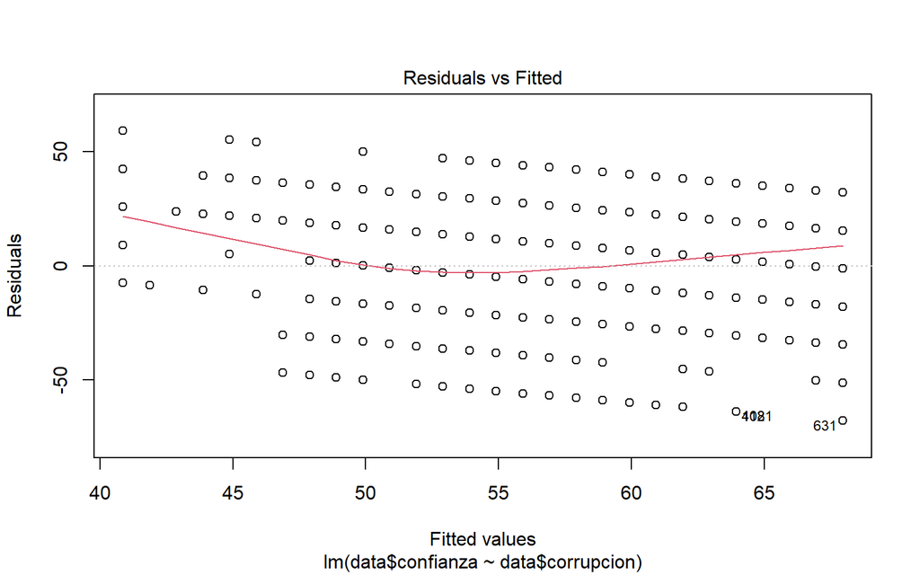

```r
plot(mod2,1)
```

```r
data$corrupcion=as.numeric(data$corrupcion)
data$confianza=as.numeric(data$confianza)
```

```r
cor.test(data$confianza, data$corrupcion)
```

```
##
##  Pearson's product-moment correlation
##
## data:  data$confianza and data$corrupcion
## t = 7.7442, df = 941, p-value = 2.482e-14
## alternative hypothesis: true correlation is not equal to 0
## 95 percent confidence interval:
##  0.1838048 0.3038644
## sample estimates:
##       cor
## 0.2447727
```

2. Observamos la normalidad de los residuos = los residuos son errores son la diferencia entre el valor predicho y observado tenemos que buscar qe sea normal y los más predominante esten en el medio y atipicos esten lejos

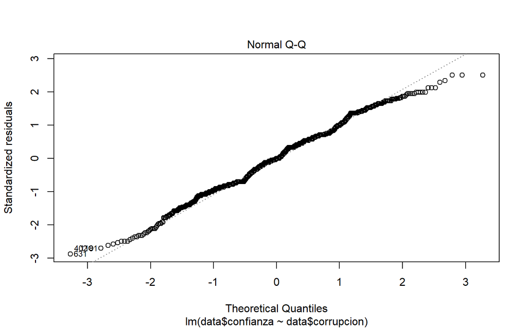

```r
plot(mod2,2)
```

```r
shapiro.test(mod2$resid)
```

```
##
##  Shapiro-Wilk normality test
##
## data:  mod2$resid
## W = 0.99264, p-value = 0.0001255
```

3. Homocedasticidad: las varianzas de errores no sean muy dispersos

```r
library(zoo)
library(lmtest)
bptest(mod2)
```

```
##
##  studentized Breusch-Pagan test
##
## data:  mod2
## BP = 1.5825, df = 1, p-value = 0.2084
```

4. La independencia de residuos, osea que sus residuos no se superpongan y no tengan relación

usamos la durbin Durbin Watson: Las hipótesis son: H0: Los residuos son independientes Ha: Los residuos no son independientes

```r
library(car)
durbinWatsonTest(mod2)
```

```
##  lag Autocorrelation D-W Statistic p-value
##    1     0.001605267      1.989638   0.816
##  Alternative hypothesis: rho != 0
```

p valor mayor a 0.05, por lo que los residuos son independientes y no hay una superposición entre ellos.

## Principales hallazgos

Como se pudo observar, el modelo multinomial pensado y establecido en la hipótesis no coincidió como modelo explicativo para el caso del nivel de confianza en las fuerzas del orden, a causa de que 2 variables en él no aportaban al modelo. Solamente el modelo de regresión lineal simple comprendido con la variable explicativa de corrupción pudo contribuir a la comprensión del fenómeno del nivel de confianza en las fuerzas del orden para la opinión pública. Esto sugiere pensar que así como se pudo comprobar en la prueba de Correlación, mientras menos se confíe en las fuerzas del orden, se cree que hay más personas involucradas en actos de corrupción para la gente.

## Conclusiones

En conclusión, se puede observar que el nivel de confianza en las fuerzas del orden se ve determinado principalmente por la presencia de corrupción en diferentes instituciones estatales. Esto a raíz del valor social que se le atribuye al rol que desempeñan las fuerzas del orden como entidad fiscalizadora y punitiva con respecto a los valores morales de esta institución para su legitimidad frente a la opinión pública adquiere relevancia. Si bien es cierto, esta investigación se realiza en base al estudio realizado por Latinobarómetro del 2018, una importante condicionante en este análisis es que el nivel de confianza tanto para las Fuerzas Armadas como para la Policía Nacional del Perú ya se encontraban recogidas por la encuesta, lo cual imposibilitó realizar un análisis más profundo acerca de qué tipo de variables condicionan este nivel de confianza o qué singularidades caracteriza cada institución en particular. Por ejemplo para el caso de las FFAA algo interesante a observar en la encuesta hubiese sido establecer si el carácter jerárquico de la institución guarda efectos para su nivel de confianza con al población.

## Bibliografía

Arhuata, A., & Edward, L. (2016). Caracterización de la confianza en las instituciones del gobierno del Perú (Doctoral dissertation, Universidad de Buenos Aires. Facultad de Ciencias Exactas y Naturales). https://bibliotecadigital.exactas.uba.ar/download/tesis/tesis_n6061_ArcayaArhuata.pdf

Carrasco Llavilla, M. S. (2016). La comunicación para volver a ganar la confianza de la ciudadanía a través de las redes sociales de la Policía Nacional del Perú. http://repositorio.bausate.edu.pe/handle/bausate/85

Cohaila, E. (2020). Confianza interpersonal y corrupción en Perú: análisis de modelos de ecuaciones estructurales. Perfiles latinoamericanos: revista de la Facultad Latinoamericana de Ciencias Sociales, Sede México, 28(56), 151-175. https://dialnet.unirioja.es/servlet/articulo?codigo=7613293

Ferrer, O. I. (2015). Percepciones sobre las Fuerzas Armadas en el continente americano. Revista Política y Estrategia, (126), 105-132. https://www.politicayestrategia.cl/index.php/rpye/article/view/65

García, L. A. M. (2017). La implementación de estrategias por parte de la Policía Nacional del Perú para la generación de confianza en el Alto Huallaga en el período 2010-2014. Pontificia Universidad Catolica del Peru-CENTRUM Catolica (Peru). https://tesis.pucp.edu.pe/repositorio/handle/20.500.12404/8044

PALMA, H., & del Perú, R. E. (1999). Desarme y seguridad: una nueva agenda de América Latina y el Caribe para el próximo milenio, Medidas Regionales de Fomento a la Confianza. Lima/Perú, dic. https://hugopalma.academy/hp-docs/06.%20El%20Fomento%20de%20la%20Confianza/Desarme%20y%20Seguridad%20Hugo%20Palma%20OPANAL%20Lima%201999.pdf

Sanjinez, V. (2017). ¿En qué instituciones confían los peruanos?. El Comercio. https://www.ipsos.com/sites/default/files/ct/news/documents/2017-10/En%20que%20instituciones%20confian%20los%20peruanos.pdf